# Bayesian GLM Part4

- neff (number of effective samples): the ratio of the number of effective samples (those not rejected by the sampler) to the number of samples provides an indication of the effectiveness (and efficiency) of the MCMC sampler. Ratios that are less than 0.5 for a parameter suggest that the sampler spent considerable time in difficult areas of the sampling domain and rejected more than half of the samples (replacing them with the previous effective sample).

  If the ratios are low, tightening the priors may help.

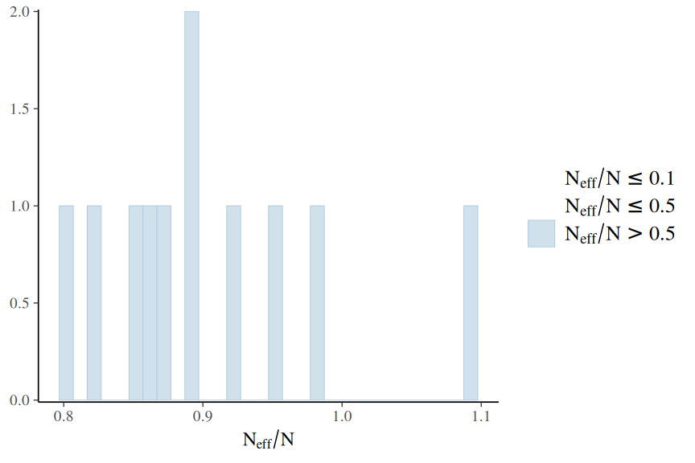

```r
plot(loyn_rstanarm3, "neff_hist")
```

Ratios all very high.

**More diagnostics**

[figure not shown]

```r
plot(loyn_rstanarm3, "combo")
```

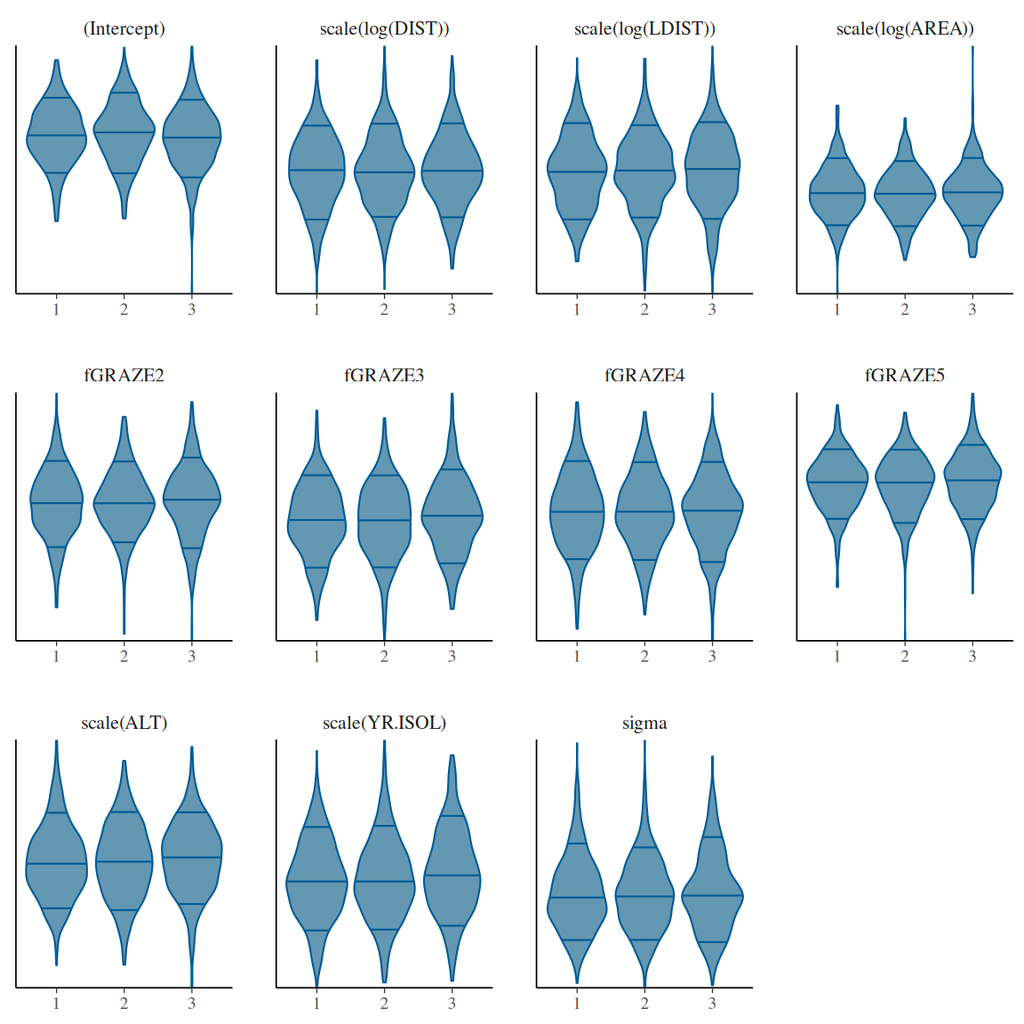

```r
plot(loyn_rstanarm3, "violin")
```

**stan plots**

The `rstan` package offers a range of MCMC diagnostics. Lets start with the MCMC diagnostics.

Of these, we will focus on:

- stan_trace: this plots the estimates of each parameter over the post-warmup length of each MCMC chain. Each chain is plotted in a different colour, with each parameter in its own facet. Ideally, each **trace** should just look like noise without any discernible drift and each of the traces for a specific parameter should look the same (i.e, should not be displaced above or below any other trace for that parameter).

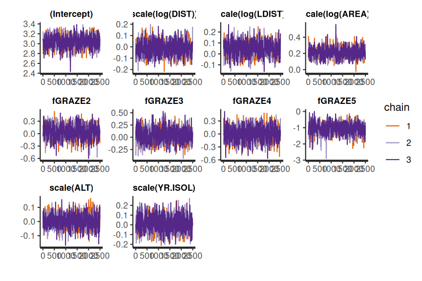

```r
stan_trace(loyn_rstanarm3)
```

The chains appear well mixed and very similar

- stan_acf (auto-correlation function): plots the auto-correlation between successive MCMC sample lags for each parameter and each chain

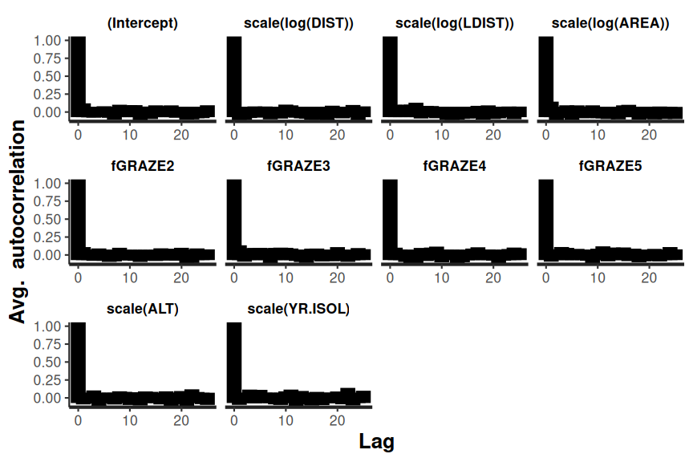

```r
stan_ac(loyn_rstanarm3)
```

There is no evidence of auto-correlation in the MCMC samples

- stan_rhat: Rhat is a **scale reduction factor** measure of convergence between the chains. The closer the values are to 1, the more the chains have converged. Values greater than 1.05 indicate a lack of convergence. There will be an Rhat value for each parameter estimated.

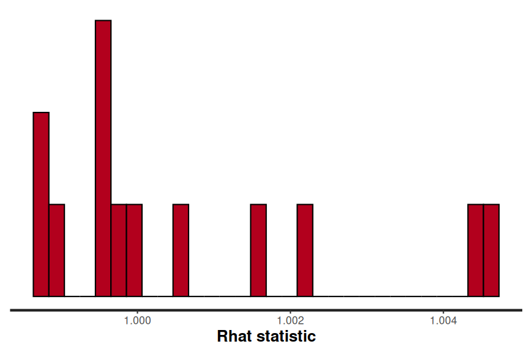

```r
stan_rhat(loyn_rstanarm3)
```

All Rhat values are below 1.05, suggesting the chains have converged.

- stan_ess (number of effective samples): the ratio of the number of effective samples (those not rejected by the sampler) to the number of samples provides an indication of the effectiveness (and efficiency) of the MCMC sampler. Ratios that are less than 0.5 for a parameter suggest that the sampler spent considerable time in difficult areas of the sampling domain and rejected more than half of the samples (replacing them with the previous effective sample).

  If the ratios are low, tightening the priors may help.

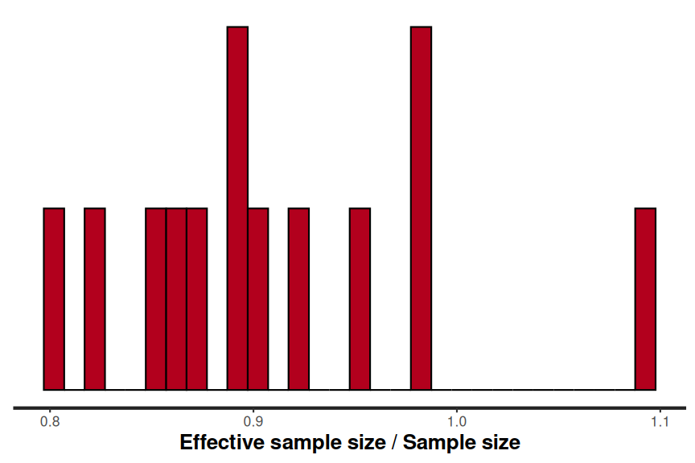

```r
stan_ess(loyn_rstanarm3)
```

Ratios all very high.

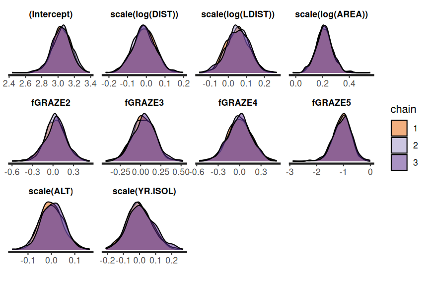

```r
stan_dens(loyn_rstanarm3, separate_chains = TRUE)
```

**ggmcmc**